# Statistical packages learning

Mohammad Hoseini  
Fall 2017

Institute for Management and Planning Studies (IMPS)

[@impsr](https://t.me/impsr)

### Why are we doing this?

To do **reproducible empirical research**

- Others can easily repeat the findings using data and codes
  - different from replication: same conclusion in a new study
- no copy-paste, no GUI use, document everything you do in codes

[figure not shown]

### Reproducibility

Raw data -> clean data -> transform -> visualize/analyze -> report

Example: bulid a province level unemployment rate from a household survey

- import raw data-files of a labor force survey
- merge the needed data files, drop unused variables, generate new variables
- aggregate the cleaned household data to province-level.
- draw a map, time-series graph, etc.
- export the results and interpret.

### Softwares

We focus on **R** and **STATA**

- graphical user interface (GUI) is available for stata & R (Rstudio) but not interesting for us. We want everything coded.

The general rules are the same in other softwares.

Important things to remember:

- file structuring
- clean coding
- variable naming and labeling

### File structuring

Separate out data, codes, output in folders.

Split long codes to multiple script files.

Place a 'Read me' file in the main folder and explain the details.

[figure not shown]

### Coding

Which one is more understandable?

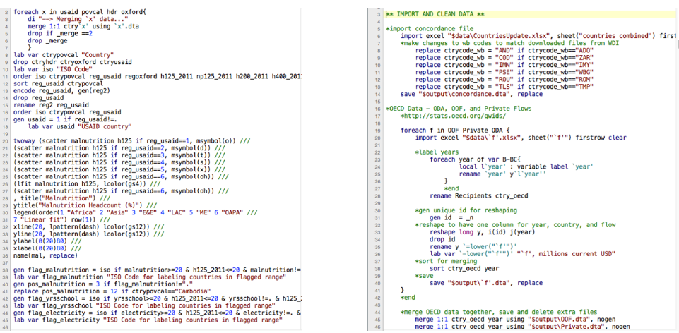

### Naming

Names are case-sensitive.

- ideally, the names are short but clear ( better to be clear than short).
- stick to a naming convention that is intuitive and consistent across your projects
- generally, function names are usually verbs, and variables are nouns.
- in **STATA** you can describe the variables using 'label var' command.

### R vs. STATA

| **R** | **STATA** |
| --- | --- |
| open source | expensive |
| closer to data science (stats/machine learning) commiunity | closer to econometricans |
| package loading structure | no hassle, much simpler syntax and module download |
| powerfull visualization (with ggplot2) | simpler visualization |
| can import many files | supports much less formats |
| poor support of Farsi | much poorer in Farsi! |
| Poor help many online resources | better standard help |
| support of Latex and better reproducibility | great GUI |
| easier writing of programs | a shared standard among economists |
| work much better with big data |  |

### By the end of the class, you will learn

How to move from **Excel** to **STATA** and **R**.

How to use a do file in **STATA** or a script in **R** to make your work reproducible.

How to manipulate data (combine, merge, summarize, work with string and factor, etc.)

How to visualize data.

How to analyze data.

How to export report to Word, Latex, Markdown, etc.

### For the next session

Take a look at: [Stata training](https://geocenter.github.io/StataTraining/)

Download and play **R** with: [DataCamp - Learn R, Python & SQL](https://play.google.com/store/apps/details?id=com.datacamp&hl=en)

[figure not shown]